# Lab 3 - Exponential Random Graph Modeling

Yun Huang

July 27, 2016

The purpose of this assignment is to familiarize yourself with Exponential Random Graph Models (ERGM’s) and their analysis using R. All questions are based on datasets that are included in R’s ERGM package.

## Part 0: Install the ERGM Package

1. Open R or R studio. Then, download and install the “ergm” and “sna” packages.

```r
#install.packages("ergm")
#install.packages("sna")
library(statnet)
```

## Part I: Hypothesis Testing on the Padget Florentine Network Using QAP

1. We will be using the Padgett Florentine family dataset. Load this network from the ergm package.

```r
data(florentine)
```

2. There are two networks in this dataset: a set of marriage ties (flomarriage) and business ties (flobusiness). Briefly describe what the nodes and edges in this network represent.
3. First, we want to plot the networks to get an idea of what they look like. Include a plot of the networks in your report.

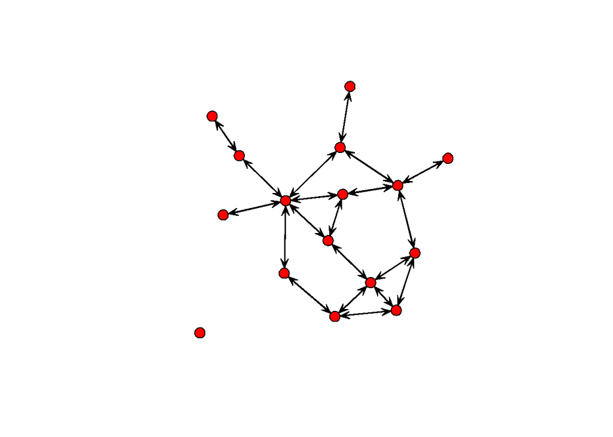

```r
gplot(flomarriage)
```

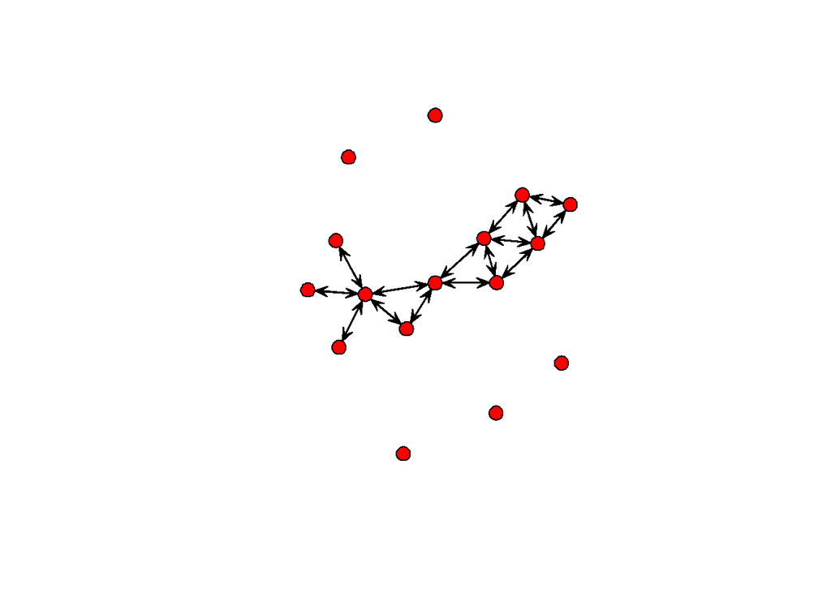

```r
gplot(flobusiness)
```

Describe some features of these graphs.

4. We want to test if there is a significant correlation between marriage and business ties. We will use QAP to determine this.

```r
G = array(dim=c(16,16,2))
G[,,1] = as.matrix(flomarriage)
G[,,2] = as.matrix(flobusiness)
Q = qaptest(G,gcor,g1=1,g2=2)
summary(Q)
```

```
##
## QAP Test Results
##
## Estimated p-values:
##  p(f(perm) >= f(d)): 0.016
##  p(f(perm) <= f(d)): 1
##
## Test Diagnostics:
##  Test Value (f(d)): 0.5735393
##  Replications: 1000
##  Distribution Summary:
##      Min:     -0.01147079
##      1stQ:    -0.01147079
##      Med:     -0.01147079
##      Mean:    -0.002110625
##      3rdQ:    -0.01147079
##      Max:     0.5735393
```

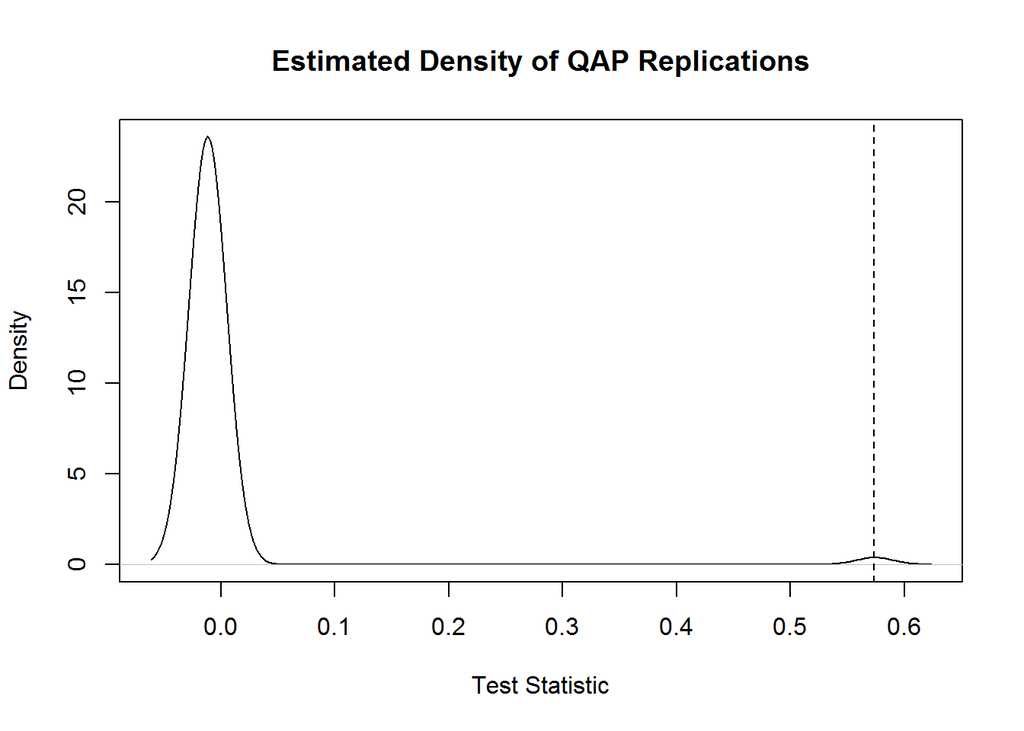

```r
plot(Q)
```

Include in your report the summary of QAP results. What is the p-value, and what is the interpretation of this value? Are marriage ties and business ties related? Include a plot of the simulated vs. realized correlation values to support your conclusion.

### Part II: Hypothesis Testing on the Padget Florentine Network Using ERGMs

5. We will be using the Padgett Florentine family dataset. Load this network from the ergm package.

```r
data(florentine)
```

6. We will start by creating a predictive model based on the edge density. The format of the ergm command is ergm(YourNetwork ~ Signature1 + Signature2 + …) where “YourNetwork” is a graph object, and the “Signatures” are aspects of the network. Note that the command format is similar to regression commands in R

```r
flo.mar.1 <- ergm(flomarriage ~ edges)
```

```
## Evaluating log-likelihood at the estimate.
```

```r
flo.mar.1
```

```
##
## MLE Coefficients:
##  edges
## -1.609
```

```r
summary(flo.mar.1)
```

```
##
## ==========================
## Summary of model fit
## ==========================
##
## Formula:   flomarriage ~ edges
##
## Iterations:  5 out of 20
##
## Monte Carlo MLE Results:
##       Estimate Std. Error MCMC % p-value
## edges  -1.6094     0.2449      0  <1e-04 ***
## ---
## Signif. codes:  0 '***' 0.001 '**' 0.01 '*' 0.05 '.' 0.1 ' ' 1
##
##      Null Deviance: 166.4  on 120  degrees of freedom
##  Residual Deviance: 108.1  on 119  degrees of freedom
##
## AIC: 110.1    BIC: 112.9    (Smaller is better.)
```

7. Describe the edge parameter that you observe, is it positive? Negative? What is the p-value? Is the edge density significant?
8. The edge parameter here is the log of the edge odds, i.e. log(#dyads-w-edge/#dyads-no-edge). We can observe that there are 20 edges in the network, and there are 120 possible. Verify that the edge parameter corresponds to the log odds

```r
log(20/(120-20))
```

```
## [1] -1.609438
```

Now, find the probability of an edge between any individual:

```r
exp(-1.609)/(1+exp(-1.609))
```

```
## [1] 0.1667275
```

In terms of probabilities, can you refine your interpretation of the edge significance?

9. Now, add the covariate “triangles” to the model.

```r
flo.mar.2 <- ergm(flomarriage ~ edges + triangles)
```

```
## Starting maximum likelihood estimation via MCMLE:
## Iteration 1 of at most 20:
## The log-likelihood improved by 0.0181
## Step length converged once. Increasing MCMC sample size.
## Iteration 2 of at most 20:
## The log-likelihood improved by 0.001678
## Step length converged twice. Stopping.
## Evaluating log-likelihood at the estimate. Using 20 bridges: 1 2 3 4 5 6 7 8 9 10 11 12 13 14 15 16 17 18 19 20 .
##
## This model was fit using MCMC.  To examine model diagnostics and check for degeneracy, use the mcmc.diagnostics() function.
```

```r
flo.mar.2
```

```
## MCMC sample of size based on:
##    edges  triangle
##  -1.6548    0.1165
##
## Monte Carlo MLE Coefficients:
##    edges  triangle
##  -1.6715    0.1524
```

```r
summary(flo.mar.2)
```

```
##
## ==========================
## Summary of model fit
## ==========================
##
## Formula:   flomarriage ~ edges + triangles
##
## Iterations:  2 out of 20
##
## Monte Carlo MLE Results:
##          Estimate Std. Error MCMC % p-value
## edges     -1.6715     0.3531      0  <1e-04 ***
## triangle   0.1524     0.6222      0   0.807
## ---
## Signif. codes:  0 '***' 0.001 '**' 0.01 '*' 0.05 '.' 0.1 ' ' 1
##
##      Null Deviance: 166.4  on 120  degrees of freedom
##  Residual Deviance: 108.1  on 118  degrees of freedom
##
## AIC: 112.1    BIC: 117.7    (Smaller is better.)
```

10. What is the outcome of the model? Report the p-values, sign, and conclusion of the hypothesis test. Do triangles drive the formation of the network?
11. ERGM’s reveal the conditional log odds of a tie occurring in the network. Conditional log-odds of a tie between two actors here

12. There are many other structures you could examine. For instance 2-stars: kstar(2), 3-stars: kstar(3) isolates: isolates, etc. Select one of these signatures and run a new model including the signature. Report the p-values and interpretation
13. Let’s run a model checking whether edges in the Florentine business network are predicted by edges in the marriage network. To do that, we can use an edge covariate parameter edgecov(). As in: ergm(MyNetwork ~ Signature1 + Signature2 + … + edgecov(AnotherNetwork)).

```r
flo.mar.3 <- ergm(flobusiness ~ edges + edgecov(flomarriage))
```

```
## Evaluating log-likelihood at the estimate.
```

```r
flo.mar.3
```

```
##
## MLE Coefficients:
##               edges  edgecov.flomarriage
##              -2.587                2.181
```

```r
summary(flo.mar.3)
```

```
##
## ==========================
## Summary of model fit
## ==========================
##
## Formula:   flobusiness ~ edges + edgecov(flomarriage)
##
## Iterations:  5 out of 20
##
## Monte Carlo MLE Results:
##                     Estimate Std. Error MCMC %  p-value
## edges                -2.5867     0.3919      0  < 1e-04 ***
## edgecov.flomarriage   2.1812     0.6016      0 0.000427 ***
## ---
## Signif. codes:  0 '***' 0.001 '**' 0.01 '*' 0.05 '.' 0.1 ' ' 1
##
##      Null Deviance: 166.36  on 120  degrees of freedom
##  Residual Deviance:  77.65  on 118  degrees of freedom
##
## AIC: 81.65    BIC: 87.22    (Smaller is better.)
```

What is the outcome of this model? Do marriage ties influence business ties?

14. We can also use node attributes in an ERGM model. For the Florentine families, we have an attribute called “wealth” in the network object. We want to test to see if nodes with higher wealth are more likely to form ties. First, create the wealth vector and visualize the network (in the graph, larger nodes represent wealthier nodes).

```r
w.vec <- flomarriage %v% 'wealth'
w.vec
```

```
##  [1]  10  36  55  44  20  32   8  42 103  48  49   3  27  10 146  48
```

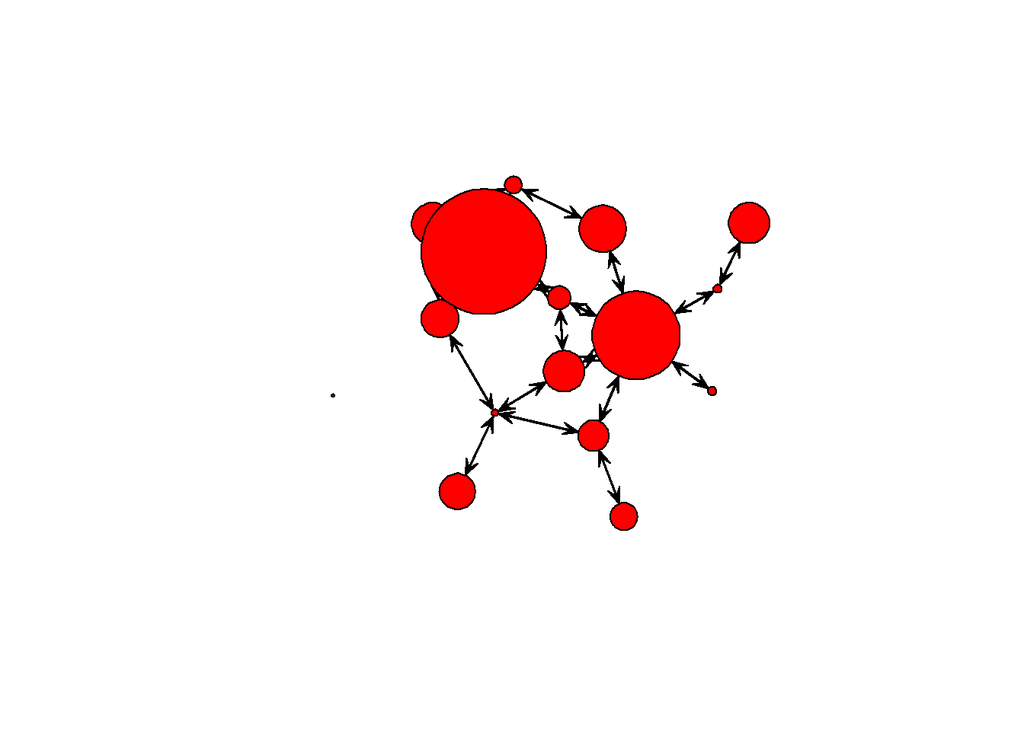

```r
gplot(flomarriage, vertex.cex=w.vec/20)
```

Now, run the ERGM model to test the hypothesis that wealthy families tend to form ties. Note the use of the nodecov (node covariate) function.

```r
flo.mar.4 <- ergm(flomarriage ~ edges + nodecov("wealth"))
```

```
## Evaluating log-likelihood at the estimate.
```

```r
summary(flo.mar.4)
```

```
##
## ==========================
## Summary of model fit
## ==========================
##
## Formula:   flomarriage ~ edges + nodecov("wealth")
##
## Iterations:  4 out of 20
##
## Monte Carlo MLE Results:
##                 Estimate Std. Error MCMC % p-value
## edges          -2.594929   0.536056      0  <1e-04 ***
## nodecov.wealth  0.010546   0.004674      0  0.0259 *
## ---
## Signif. codes:  0 '***' 0.001 '**' 0.01 '*' 0.05 '.' 0.1 ' ' 1
##
##      Null Deviance: 166.4  on 120  degrees of freedom
##  Residual Deviance: 103.1  on 118  degrees of freedom
##
## AIC: 107.1    BIC: 112.7    (Smaller is better.)
```

What can you conclude? Report p-values and outcome of the hypothesis test.

15. Finally, we can use functions of node attributes to make predictions. Consider building a model based on the absolute difference in family wealth.

```r
flo.mar.5 <- ergm(flomarriage ~ edges + absdiff("wealth"))
```

```
## Evaluating log-likelihood at the estimate.
```

```r
summary(flo.mar.5)
```

```
##
## ==========================
## Summary of model fit
## ==========================
##
## Formula:   flomarriage ~ edges + absdiff("wealth")
##
## Iterations:  4 out of 20
##
## Monte Carlo MLE Results:
##                 Estimate Std. Error MCMC % p-value
## edges          -2.302042   0.401906      0  <1e-04 ***
## absdiff.wealth  0.015519   0.006157      0  0.0131 *
## ---
## Signif. codes:  0 '***' 0.001 '**' 0.01 '*' 0.05 '.' 0.1 ' ' 1
##
##      Null Deviance: 166.4  on 120  degrees of freedom
##  Residual Deviance: 102.0  on 118  degrees of freedom
##
## AIC: 106    BIC: 111.5    (Smaller is better.)
```

Interpret your findings. What does the sign and significance of the absdiff() coefficient mean?

16. Now, it is your turn to come up with a model. Using the code you have seen up to this point, come up with a unique hypothesis concerning business ties, marriage ties, wealth, or their combinations. Include the code for this model, a summary of the output, and your interpretation. You will be graded on creativity and interpretation, not complexity.

Part III: Goodness of Fit and Model Diagnostics 1) After estimating parameters for your mode, you want to know how well it fits the observed data. We will use a goodness of fit procedure to generate a probability distribution for the degree distribution of a graph, and compare it to the observed instance. Check the goodness of fit for the degree:

```r
flo.mar.4.gof <- gof(flo.mar.4 ~ degree)
flo.mar.4.gof
```

```
##
## Goodness-of-fit for degree
##
##    obs min mean max MC p-value
## 0    1   0 1.40   5       1.00
## 1    4   0 3.12   9       0.80
## 2    2   0 4.24  10       0.32
## 3    6   0 3.44   8       0.12
## 4    2   0 2.01   6       1.00
## 5    0   0 1.00   5       0.76
## 6    1   0 0.48   3       0.78
## 7    0   0 0.20   1       1.00
## 8    0   0 0.08   1       1.00
## 9    0   0 0.02   1       1.00
## 10   0   0 0.01   1       1.00
```

2. Plot the goodness of fit. Save a copy for your report.

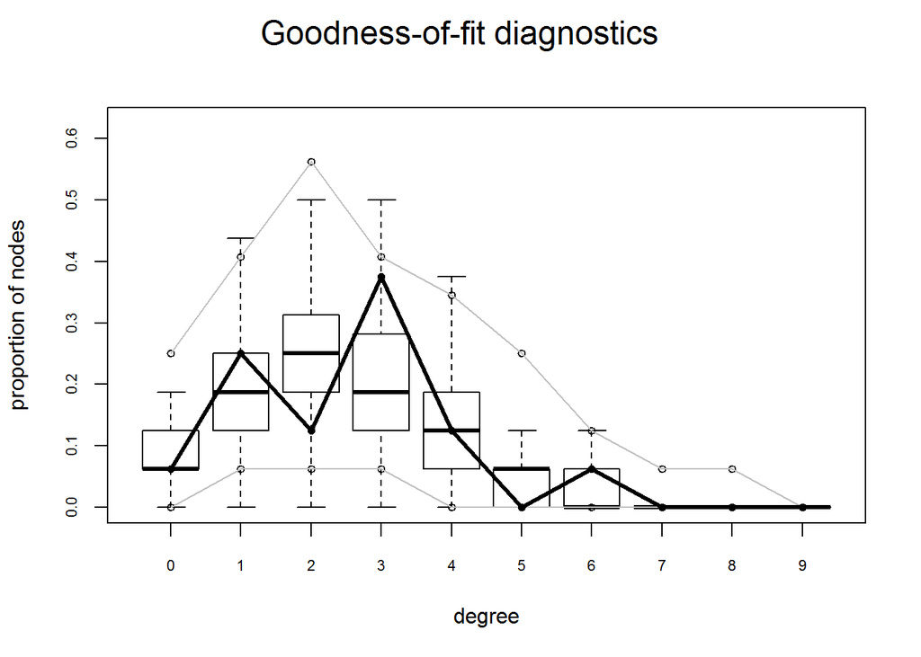

```r
plot(flo.mar.4.gof)
```

3) Is the model a good fit? Do the estimates lie within the confidence intervals? Use the plot as well as the summary of the test to determine if the observed models match the model.

```r
flo.mar.4.gof2 <- gof(flo.mar.4 ~ distance, nsim=20) # gof based on 20 simulated nets
summary(flo.mar.4.gof2)
```

```
##
## Goodness-of-fit for minimum geodesic distance
##
##     obs min  mean max MC p-value
## 1    20  12 20.21  32       1.00
## 2    35  14 34.61  62       1.00
## 3    32  10 26.63  41       0.44
## 4    15   1 11.35  26       0.56
## 5     3   0  3.38  16       0.84
## 6     0   0  0.92   9       1.00
## 7     0   0  0.26   7       1.00
## 8     0   0  0.07   6       1.00
## Inf  15   0 22.57  81       1.00
```

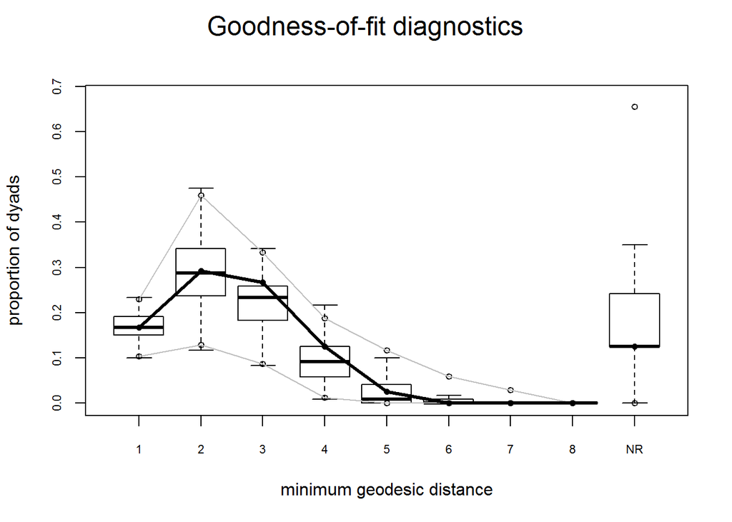

```r
plot(flo.mar.4.gof2)
```

Is the model a good fit based on geodesic distance? Report based on the goodness of fit test and the plot. Save a copy of your plot with your report.

5. Because some of our models were estimated using Markov Chain Monte Carlo methods (MCMC), we need to run diagnostics to see if the models converged properly. Note we can’t get (and don’t need) these diagnostics for flo.mar.4 since it was not estimated using MCMC. This is because it was simple enough (i.e. a dyadic independence model) that we did not need MCMC estimation. However, our edge-triangle model did. Run the following commands. To view the plots better, try saving as a pdf (include the images in your report).

```
## Sample statistics summary:
##
## Iterations = 16384:4209664
## Thinning interval = 1024
## Number of chains = 1
## Sample size per chain = 4096
##
## 1. Empirical mean and standard deviation for each variable,
##    plus standard error of the mean:
##
##              Mean    SD Naive SE Time-series SE
## edges     0.02368 4.339  0.06779        0.06586
## triangle -0.08252 2.462  0.03847        0.03847
##
## 2. Quantiles for each variable:
##
##          2.5% 25% 50% 75% 97.5%
## edges      -8  -3   0   3     9
## triangle   -3  -2  -1   1     6
##
##
## Sample statistics cross-correlations:
##              edges  triangle
## edges    1.0000000 0.7574658
## triangle 0.7574658 1.0000000
##
## Sample statistics auto-correlation:
## Chain 1
##                 edges     triangle
## Lag 0     1.000000000  1.000000000
## Lag 1024  0.003887755  0.006933399
## Lag 2048 -0.032957026 -0.022295048
## Lag 3072 -0.012420956  0.012109491
## Lag 4096  0.017705905  0.004847643
## Lag 5120 -0.019198825 -0.009544945
##
## Sample statistics burn-in diagnostic (Geweke):
## Chain 1
##
## Fraction in 1st window = 0.1
## Fraction in 2nd window = 0.5
##
##    edges triangle
##  -0.7450  -0.4938
##
## Individual P-values (lower = worse):
##     edges  triangle
## 0.4562989 0.6214444
## Joint P-value (lower = worse):  0.7846236 .
```

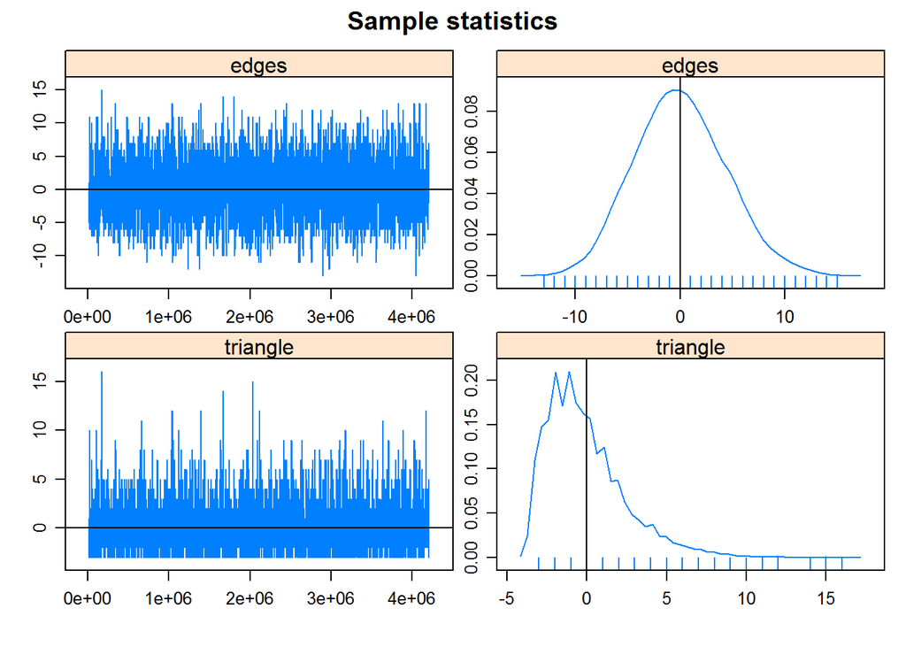

[output not shown]

```r
mcmc.diagnostics(flo.mar.2)  # Use only this if you want R images
```

The left plot is called a trace plot - it shows the values the parameter took during the runtime of the chain. The right plot is usually called a marginal density plot. Basically, it is the (smoothened) histogram of the values in the trace-plot, i.e. the distribution of the values of the parameter in the chain. Do the variables look stable around their estimated values? Did the model converge?